# DATA621-Homework3-HoddeFarrisBurmoodLin

Rob Hodde, Matt Farris, Jeffrey Burmood, Bin Lin

4/05/2017

### Problem Description

Explore, analyze and model a data set containing information on crime for various neighborhoods of a major city. Using the data set build a binary logistic regression model on the training data set to predict whether the neighborhood will be at risk for high crime levels. Provide classifications and probabilities for the evaluation data set using the developed binary logistic regression model.

## Data Exploration

The first thirteen variables in the table below are potential predictor variables that could affect the response variable *target*.

| Variable | Type | Definition |
| --- | --- | --- |
| zn | Double | proportion of residential land zoned for large lots |
| indus | Double | proportion of non-retail business acres per suburb |
| chas | Integer | suburb borders the Charles River (1 = Yes, 0 = No) |
| nox | Double | nitrogen oxides concentration (parts per 10 million) |
| rm | Double | average number of rooms per dwelling |
| age | Double | proportion of owner-occupied units built prior to 1940 |
| dis | Double | mean of distances to five Boston employment centers |
| rad | Integer | index of accessibility to radial highways |
| tax | Integer | full-value property-tax rate per $10,000 |
| ptratio | Double | pupil-teacher ratio by town |
| black | Double | 1000(Bk - 0.63)2 where Bk = proportion of blacks by town |
| lstat | Double | lower status of the population (percent) |
| medv | Double | median value of owner-occupied homes in $1000s |
| target | Integer | crime rate is above the median crime rate (1 = Yes, 0 = No) |

Below is a summary of each predictor variable’s basic statistics, followed by boxplots which illustrate the spread and outliers for each variable.

|  | zn | indus | chas | nox | rm | age |
| --- | --- | --- | --- | --- | --- | --- |
|  | Min. : 0.00 | Min. : 0.460 | Min. :0.00000 | Min. :0.3890 | Min. :3.863 | Min. : 2.90 |
|  | 1st Qu.: 0.00 | 1st Qu.: 5.145 | 1st Qu.:0.00000 | 1st Qu.:0.4480 | 1st Qu.:5.887 | 1st Qu.: 43.88 |
|  | Median : 0.00 | Median : 9.690 | Median :0.00000 | Median :0.5380 | Median :6.210 | Median : 77.15 |
|  | Mean : 11.58 | Mean :11.105 | Mean :0.07082 | Mean :0.5543 | Mean :6.291 | Mean : 68.37 |
|  | 3rd Qu.: 16.25 | 3rd Qu.:18.100 | 3rd Qu.:0.00000 | 3rd Qu.:0.6240 | 3rd Qu.:6.630 | 3rd Qu.: 94.10 |
|  | Max. :100.00 | Max. :27.740 | Max. :1.00000 | Max. :0.8710 | Max. :8.780 | Max. :100.00 |

|  | dis | rad | tax | ptratio | black | lstat |
| --- | --- | --- | --- | --- | --- | --- |
|  | Min. : 1.130 | Min. : 1.00 | Min. :187.0 | Min. :12.6 | Min. : 0.32 | Min. : 1.730 |
|  | 1st Qu.: 2.101 | 1st Qu.: 4.00 | 1st Qu.:281.0 | 1st Qu.:16.9 | 1st Qu.:375.61 | 1st Qu.: 7.043 |
|  | Median : 3.191 | Median : 5.00 | Median :334.5 | Median :18.9 | Median :391.34 | Median :11.350 |
|  | Mean : 3.796 | Mean : 9.53 | Mean :409.5 | Mean :18.4 | Mean :357.12 | Mean :12.631 |
|  | 3rd Qu.: 5.215 | 3rd Qu.:24.00 | 3rd Qu.:666.0 | 3rd Qu.:20.2 | 3rd Qu.:396.24 | 3rd Qu.:16.930 |
|  | Max. :12.127 | Max. :24.00 | Max. :711.0 | Max. :22.0 | Max. :396.90 | Max. :37.970 |

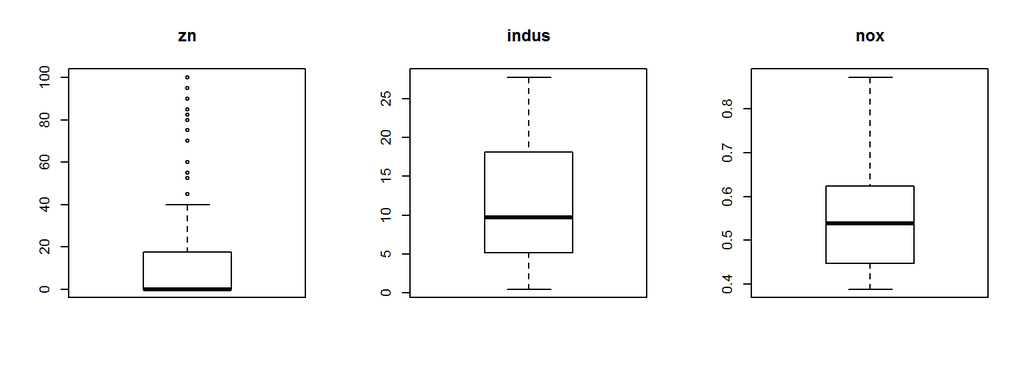

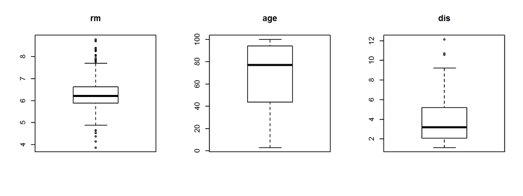

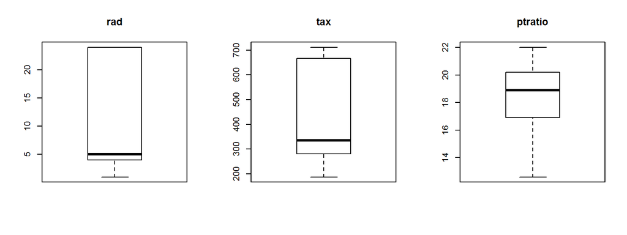

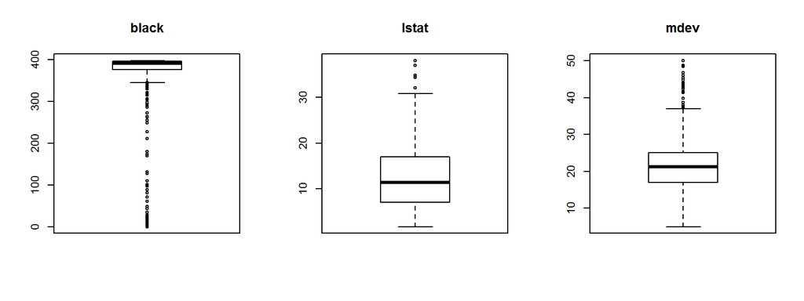

Based on an analysis of the box plots, the following variables have some outliers that may, or may not, exert influence on the regression results: - zn, rm, dis, black, lstat, medv

We’ll next look at these variables more closely, starting with their histograms and frequency counts to better understand the nature of their distribution.

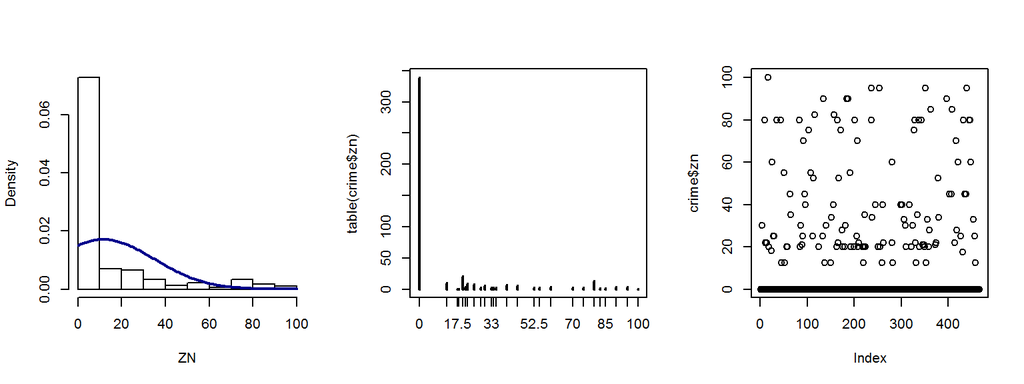

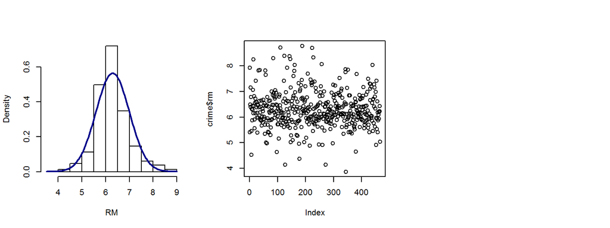

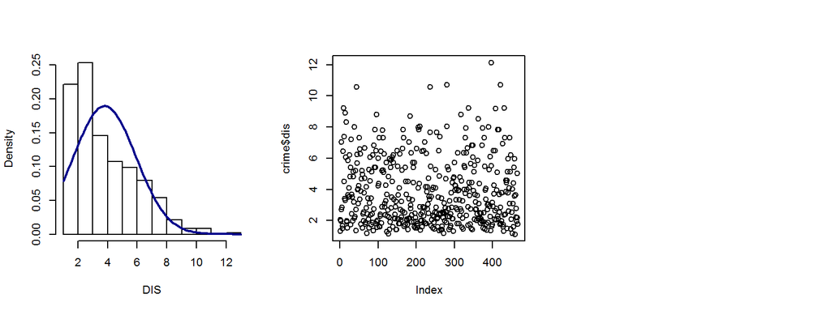

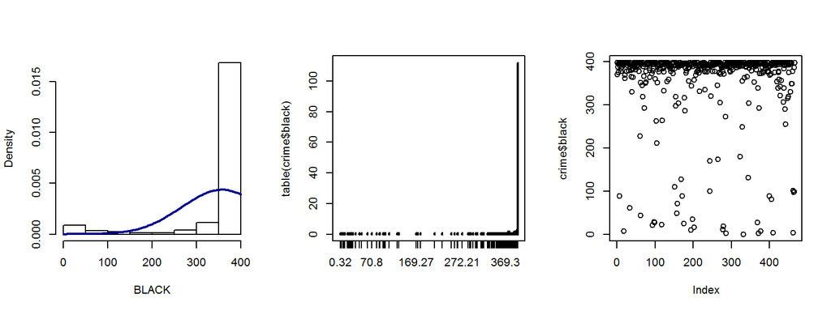

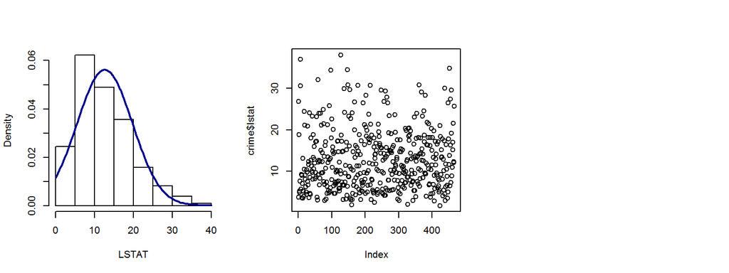

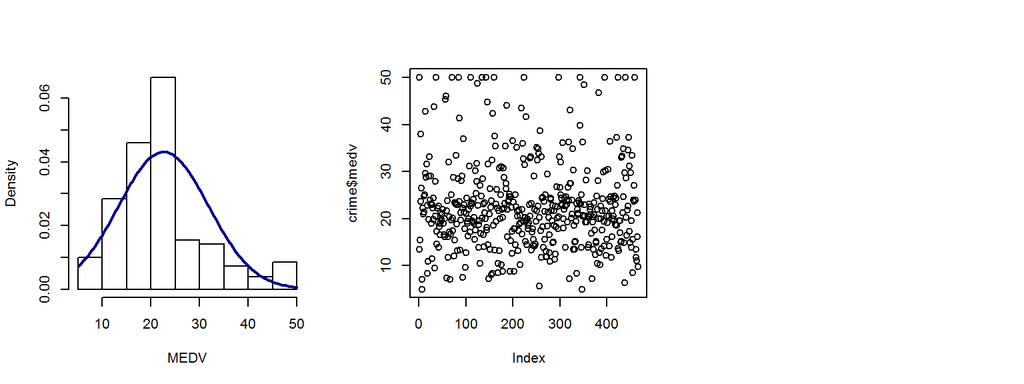

Based on our detailed review of the variables that contained outliers, the following variables could be problematic:

The predictor variable *zn* is highly right skewed, we can confirm this by comparing the median and mean where the median is 0.0, but the mean is 11.58. The frequency count plot shows how poor the distribution is due to clustering of the data at one extreme.

The predictor variable *black* is highly left skewed. We can confirm this by comparing the median and mean where the median is 391.34 and the mean is 357.12. The frequency count plot shows how poor the distribution is due to clustering of the data at one extreme.

The predictor variable *dis* is slightly right skewed. We can confirm this by comparing the median and mean where the median is 3.191 and the mean is 3.796.

Fortunately, no missing data, or NAs, were found.

The following data corrections were identified in this section:

1. The predictor variable *chas* and the response variable *target* are categorical (binary), so we need to convert them to factors.
2. Need to determine if there are other variables highly coorelated with the *zn* or *black* variables that do not have the severe skew and outliers. This could allow us to remove the *zn* or *black* variables from the model.

## Data Preparation

The variable changes we identified so far include converting the predictor variable *chas* and the response variable *target* to factors. Next we will look at how each variable correlates to all the others:

|  | zn | indus | nox | rm | age | dis |
| --- | --- | --- | --- | --- | --- | --- |
| zn | 1.0000000 | -0.5382664 | -0.5170452 | 0.3198141 | -0.5725805 | 0.6601243 |
| indus | -0.5382664 | 1.0000000 | 0.7596301 | -0.3927118 | 0.6395818 | -0.7036189 |
| nox | -0.5170452 | 0.7596301 | 1.0000000 | -0.2954897 | 0.7351278 | -0.7688840 |
| rm | 0.3198141 | -0.3927118 | -0.2954897 | 1.0000000 | -0.2328125 | 0.1990158 |
| age | -0.5725805 | 0.6395818 | 0.7351278 | -0.2328125 | 1.0000000 | -0.7508976 |
| dis | 0.6601243 | -0.7036189 | -0.7688840 | 0.1990158 | -0.7508976 | 1.0000000 |
| rad | -0.3154812 | 0.6006284 | 0.5958298 | -0.2084457 | 0.4603143 | -0.4949919 |
| tax | -0.3192841 | 0.7322292 | 0.6538780 | -0.2969343 | 0.5121245 | -0.5342546 |
| ptratio | -0.3910357 | 0.3946898 | 0.1762687 | -0.3603471 | 0.2554479 | -0.2333394 |
| black | 0.1794150 | -0.3581356 | -0.3801549 | 0.1326676 | -0.2734677 | 0.2938441 |
| lstat | -0.4329925 | 0.6071102 | 0.5962426 | -0.6320245 | 0.6056200 | -0.5075280 |
| medv | 0.3767171 | -0.4961743 | -0.4301227 | 0.7053368 | -0.3781560 | 0.2566948 |

|  | rad | tax | ptratio | black | lstat | medv |
| --- | --- | --- | --- | --- | --- | --- |
| zn | -0.3154812 | -0.3192841 | -0.3910357 | 0.1794150 | -0.4329925 | 0.3767171 |
| indus | 0.6006284 | 0.7322292 | 0.3946898 | -0.3581356 | 0.6071102 | -0.4961743 |
| nox | 0.5958298 | 0.6538780 | 0.1762687 | -0.3801549 | 0.5962426 | -0.4301227 |
| rm | -0.2084457 | -0.2969343 | -0.3603471 | 0.1326676 | -0.6320245 | 0.7053368 |
| age | 0.4603143 | 0.5121245 | 0.2554479 | -0.2734677 | 0.6056200 | -0.3781560 |
| dis | -0.4949919 | -0.5342546 | -0.2333394 | 0.2938441 | -0.5075280 | 0.2566948 |
| rad | 1.0000000 | 0.9064632 | 0.4714516 | -0.4463750 | 0.5031013 | -0.3976683 |
| tax | 0.9064632 | 1.0000000 | 0.4744223 | -0.4425059 | 0.5641886 | -0.4900329 |
| ptratio | 0.4714516 | 0.4744223 | 1.0000000 | -0.1816395 | 0.3773560 | -0.5159153 |
| black | -0.4463750 | -0.4425059 | -0.1816395 | 1.0000000 | -0.3533659 | 0.3300286 |
| lstat | 0.5031013 | 0.5641886 | 0.3773560 | -0.3533659 | 1.0000000 | -0.7358008 |
| medv | -0.3976683 | -0.4900329 | -0.5159153 | 0.3300286 | -0.7358008 | 1.0000000 |

The correlation table above shows that the variable *zn* is moderately correlated to the variable *dis*. The plot of the *dis* data shows a much better distribution of values. Consequently, one possibility is to remove *zn* from the model and use *dis* instead. Before doing this, we should look at the real-world context of the two variables to determine if they are meaningfully related.

## Build Models

One method of developing multiple regression models is to take a stepwise approach. To accomplish this, we combine our knowledge from the data exploration above with logistic regression. Univariate Logistic Regression is a useful method to understand how each predictor variable interacts individually with the target (response) variable. Looking at various statistics, we determine which variable may impact our target the most.

| var | p_val | aic | auc |
| --- | --- | --- | --- |
| zn | 0.0000000 | 413.2878 | 0.7076814 |
| indus | 0.0000000 | 345.8163 | 0.8091513 |
| chas1 | 0.3188437 | 518.3011 | 0.5452821 |
| nox | 0.0000000 | 212.6269 | 0.8710289 |
| rm | 0.0010624 | 507.8644 | 0.5737316 |
| age | 0.0000000 | 317.3847 | 0.7937411 |
| dis | 0.0000000 | 307.0926 | 0.7970602 |
| rad | 0.0000015 | 330.3616 | 0.8440019 |
| tax | 0.0000000 | 353.7222 | 0.8319109 |
| ptratio | 0.0000011 | 493.3566 | 0.6600284 |
| black | 0.0000018 | 435.2948 | 0.7484590 |
| lstat | 0.0000000 | 416.8908 | 0.7015173 |

We examine the p-value (significance), the AIC statistic (goodness-of-fit) and the AUC (Area Under Curve) to measure the potential predictive value of each variable, so we can decide whether or not to include it in our multiple regression model. We are looking for p-values below .05, AIC values as low as possible, and AUC values as high as possible.

From the above table, we can see that *chas* is the least likely to produce any meaningful inference because its p-value is well above .05 (not significant), it has the highest AIC (518, where 100 is considered excellent), and the lowest AUC (.54, where random chance would yield .50). Therefore, *chas* is the most likely candidate to be removed from our model.

### Model 1

As a baseline, we start with a multiple logistic regression model that includes every predictor variable:

```
##
## Call:
## glm(formula = target ~ ., family = binomial(link = "logit"),
##     data = train)
##
## Deviance Residuals:
##     Min       1Q   Median       3Q      Max
## -1.7132  -0.0934   0.0000   0.0016   3.4718
##
## Coefficients:
##               Estimate Std. Error z value Pr(>|z|)
## (Intercept) -24.342449   9.762679  -2.493 0.012652 *
## zn           -0.038247   0.038733  -0.987 0.323420
## indus        -0.082035   0.066940  -1.225 0.220391
## chas1         1.189371   0.904623   1.315 0.188587
## nox          53.285171  10.168667   5.240  1.6e-07 ***
## rm           -1.183564   0.917904  -1.289 0.197252
## age           0.054774   0.016677   3.284 0.001022 **
## dis           0.710750   0.286890   2.477 0.013233 *
## rad           0.703069   0.203161   3.461 0.000539 ***
## tax          -0.010313   0.004648  -2.219 0.026491 *
## ptratio       0.560259   0.180922   3.097 0.001957 **
## black        -0.044213   0.018559  -2.382 0.017206 *
## lstat        -0.046652   0.067660  -0.690 0.490500
## medv          0.187979   0.084565   2.223 0.026223 *
## ---
## Signif. codes:  0 '***' 0.001 '**' 0.01 '*' 0.05 '.' 0.1 ' ' 1
##
## (Dispersion parameter for binomial family taken to be 1)
##
##     Null deviance: 515.31  on 371  degrees of freedom
## Residual deviance: 130.18  on 358  degrees of freedom
## AIC: 158.18
##
## Number of Fisher Scoring iterations: 9
```

```
## [1] 0.9506875
```

```
##           Reference
## Prediction  0  1
##          0 48  4
##          1  9 33
```

### Model 2

In this scenario we attempt to create the simplest model possible by using only one variable - the one that provides the highest overall AUC (performance) by itself. We calculate AUC for each variable separately and then select the highest result.

```
## [1] 0.8710289
```

The best predictor variable is *nox*, yielding an AUC of .87.

Next we combine *nox* with each of the remaining variables individually and select the highest AUC result.

```
## [1] 0.9338549
```

We find that *nox* plus *rad* is the strongest combinaton of two variables, yielding an AUC of .93.

Finally, we search for a third critical predictor by combining *nos* plus *rad* with the remaining variables, individually.

```
## [1] 0.9419156
```

```
##           Reference
## Prediction  0  1
##          0 51  7
##          1  6 30
```

### Model 3

The GLM Model summary in Model 1 illustrates the outsize impact of the predictor variable *nox* compared to all the others. It carries an Estimate of 53.3 where the next closest in magnitude is only 1.2. We thought it would be interesting to remove *nox* from the model just to see how the other variables perform without it. First we will perform a simple backward variable selection optimization process including it.

#### MODEL 3 WITH NOX VARIABLE

```
## Start:  AIC=158.18
## target ~ zn + indus + chas + nox + rm + age + dis + rad + tax +
##     ptratio + black + lstat + medv
##
##           Df Deviance    AIC
## - lstat    1   130.66 156.66
## - zn       1   131.32 157.32
## - indus    1   131.71 157.71
## - rm       1   131.88 157.88
## - chas     1   131.90 157.90
## <none>         130.18 158.18
## - medv     1   135.74 161.74
## - tax      1   135.83 161.83
## - dis      1   137.13 163.13
## - black    1   141.32 167.32
## - ptratio  1   141.36 167.36
## - age      1   142.62 168.62
## - rad      1   160.19 186.19
## - nox      1   179.04 205.04
##
## Step:  AIC=156.66
## target ~ zn + indus + chas + nox + rm + age + dis + rad + tax +
##     ptratio + black + medv
##
##           Df Deviance    AIC
## - rm       1   131.88 155.88
## - zn       1   131.97 155.97
## - chas     1   132.07 156.07
## - indus    1   132.13 156.13
## <none>         130.66 156.66
## - medv     1   135.85 159.85
## - tax      1   137.03 161.03
## - dis      1   137.28 161.28
## - ptratio  1   141.42 165.42
## - black    1   141.78 165.78
## - age      1   143.67 167.67
## - rad      1   161.04 185.04
## - nox      1   179.22 203.22
##
## Step:  AIC=155.88
```

[output cut: 34 more lines]

```
## Step:  AIC=153.91
## target ~ zn + nox + age + dis + rad + tax + ptratio + black +
##     medv
##
##           Df Deviance    AIC
## <none>         133.91 153.91
## - zn       1   135.92 153.92
## - dis      1   138.75 156.75
## - medv     1   139.87 157.87
## - ptratio  1   141.76 159.76
## - black    1   144.48 162.48
## - age      1   146.79 164.79
## - tax      1   149.18 167.18
## - rad      1   174.36 192.36
## - nox      1   185.81 203.81
```

```
##
## Call:
## glm(formula = target ~ zn + nox + age + dis + rad + tax + ptratio +
##     black + medv, family = binomial(link = "logit"), data = train)
##
## Deviance Residuals:
##     Min       1Q   Median       3Q      Max
## -1.8622  -0.1135   0.0000   0.0018   3.3120
##
## Coefficients:
##               Estimate Std. Error z value Pr(>|z|)
## (Intercept) -21.935844   9.197361  -2.385 0.017078 *
## zn           -0.048462   0.037132  -1.305 0.191848
## nox          44.193814   7.922146   5.579 2.43e-08 ***
## age           0.043782   0.013013   3.364 0.000767 ***
## dis           0.551173   0.260500   2.116 0.034359 *
## rad           0.764131   0.188980   4.043 5.27e-05 ***
## tax          -0.013328   0.004197  -3.176 0.001496 **
## ptratio       0.396941   0.145949   2.720 0.006534 **
## black        -0.041476   0.017228  -2.408 0.016062 *
## medv          0.097180   0.042373   2.293 0.021823 *
## ---
## Signif. codes:  0 '***' 0.001 '**' 0.01 '*' 0.05 '.' 0.1 ' ' 1
##
## (Dispersion parameter for binomial family taken to be 1)
##
##     Null deviance: 515.31  on 371  degrees of freedom
## Residual deviance: 133.91  on 362  degrees of freedom
## AIC: 153.91
##
## Number of Fisher Scoring iterations: 9
```

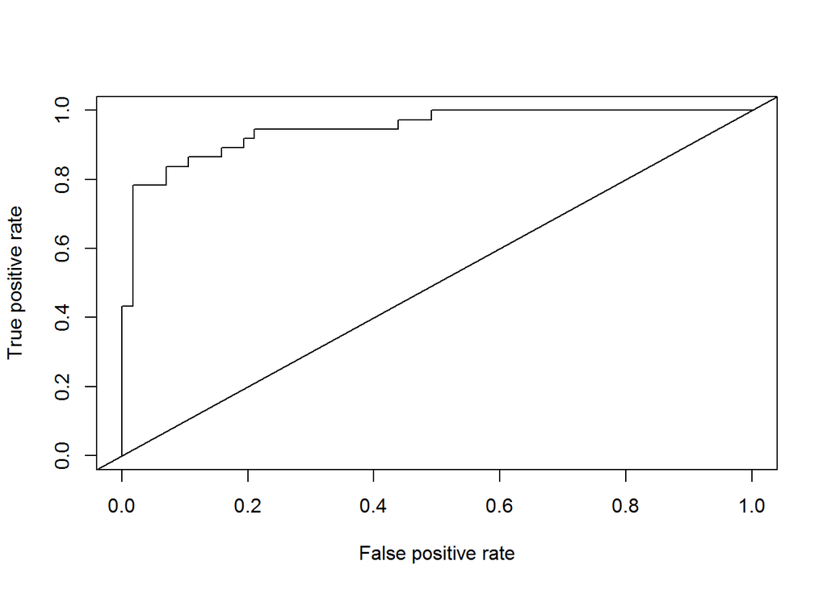

```
## [1] 0.9468943
```

```
##           Reference
## Prediction  0  1
##          0 48  5
##          1  9 32
```

Let’s look at what happens when we remove the *nox* variable:

#### MODEL 3 WITHOUT NOX VARIABLE

```
## Start:  AIC=205.04
## target ~ (zn + indus + chas + nox + rm + age + dis + rad + tax +
##     ptratio + black + lstat + medv) - nox
##
##           Df Deviance    AIC
## - rm       1   179.04 203.04
## - lstat    1   179.22 203.22
## - medv     1   179.49 203.49
## - ptratio  1   179.50 203.50
## - zn       1   179.72 203.72
## - chas     1   180.12 204.12
## <none>         179.04 205.04
## - dis      1   184.69 208.69
## - indus    1   185.26 209.26
## - tax      1   189.25 213.25
## - age      1   194.42 218.42
## - black    1   194.48 218.48
## - rad      1   224.28 248.28
##
## Step:  AIC=203.04
## target ~ zn + indus + chas + age + dis + rad + tax + ptratio +
##     black + lstat + medv
##
##           Df Deviance    AIC
## - lstat    1   179.24 201.24
## - ptratio  1   179.55 201.55
## - zn       1   179.74 201.74
## - chas     1   180.14 202.14
## - medv     1   180.33 202.33
## <none>         179.04 203.04
## - dis      1   184.75 206.75
## - indus    1   185.26 207.26
## - tax      1   189.48 211.48
## - black    1   194.49 216.49
## - age      1   199.65 221.65
## - rad      1   224.29 246.29
##
## Step:  AIC=201.23
## target ~ zn + indus + chas + age + dis + rad + tax + ptratio +
##     black + medv
```

[output cut: 53 more lines]

```
## - black  1   196.02 210.02
## - age    1   206.37 220.37
## - rad    1   230.37 244.37
##
## Step:  AIC=196.11
## target ~ indus + age + dis + rad + tax + black
##
##         Df Deviance    AIC
## <none>       182.11 196.11
## - indus  1   187.66 199.66
## - tax    1   193.45 205.45
## - dis    1   193.52 205.52
## - black  1   196.74 208.74
## - age    1   206.70 218.70
## - rad    1   231.11 243.11
```

```
##
## Call:
## glm(formula = target ~ indus + age + dis + rad + tax + black,
##     family = binomial(link = "logit"), data = train)
##
## Deviance Residuals:
##     Min       1Q   Median       3Q      Max
## -2.3129  -0.3415   0.0000   0.0139   2.6900
##
## Coefficients:
##              Estimate Std. Error z value Pr(>|z|)
## (Intercept) 12.339156   5.329705   2.315  0.02060 *
## indus        0.112098   0.050765   2.208  0.02723 *
## age          0.047489   0.010497   4.524 6.06e-06 ***
## dis         -0.475263   0.148846  -3.193  0.00141 **
## rad          0.647494   0.160850   4.025 5.69e-05 ***
## tax         -0.011195   0.003676  -3.045  0.00232 **
## black       -0.039095   0.013024  -3.002  0.00268 **
## ---
## Signif. codes:  0 '***' 0.001 '**' 0.01 '*' 0.05 '.' 0.1 ' ' 1
##
## (Dispersion parameter for binomial family taken to be 1)
##
##     Null deviance: 515.31  on 371  degrees of freedom
## Residual deviance: 182.11  on 365  degrees of freedom
## AIC: 196.11
##
## Number of Fisher Scoring iterations: 9
```

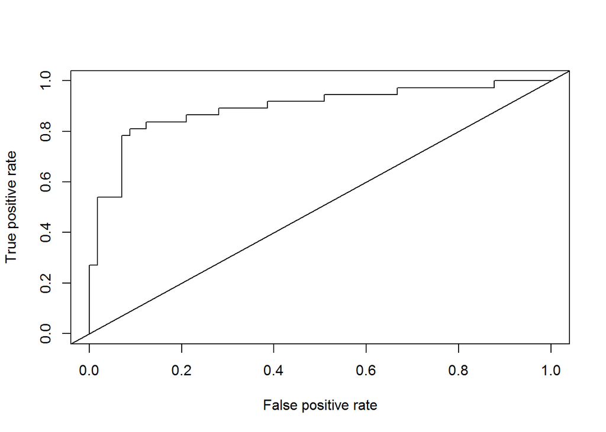

```
## [1] 0.8933144
```

We still have a good model - the Residual Deviance increased to 182, but that is still much better than predicting with no model at all. The AUC is now .89 - again, very good. But the AUC with only one variable *nox* was .87. And in certain trials the AUC with *nox* exceeded .95 (due to randomly selected evaluation samples).

Why is the *nox* variable so powerful? We can look back at the Correlation table for clues. More variables are significantly correlated to *nox* than any other. It is like a super-variable, somehow encapsulating the properties of the variables around it. Is it because *nox* is an indicator of so many problems, like pollution, industrial decay, lax building codes? The *nox* variable is a stellar example of a finding that opens up many paths for further research.

Below is table illustrating the various fitness parameters that describe the effectiveness of the models. All the models are good - from a practical perspective, there is no difference between them.

| Parameters | Model1 | Model2 | Model3 |
| --- | --- | --- | --- |
| Accuracy | 0.8617021 | 0.8617021 | 0.8510638 |
| Classification Error Rate | 0.1382979 | 0.1382979 | 0.1489362 |
| Precision | 0.9230769 | 0.8793103 | 0.9056604 |
| Sensitivity | 0.8421053 | 0.8947368 | 0.8421053 |
| Specificity | 0.8918919 | 0.8108108 | 0.8648649 |
| F1 Score | 0.8807339 | 0.8869565 | 0.8727273 |

## Choose Model

#### MODEL 3 WITH NOX VARIABLE USING FULL DATASETS

```
##
## Call:
## glm(formula = target ~ zn + nox + age + dis + rad + tax + ptratio +
##     black + medv, family = binomial(link = "logit"), data = crime)
##
## Deviance Residuals:
##     Min       1Q   Median       3Q      Max
## -2.2719  -0.1695  -0.0022   0.0022   3.4083
##
## Coefficients:
##               Estimate Std. Error z value Pr(>|z|)
## (Intercept) -33.252218   6.510006  -5.108 3.26e-07 ***
## zn           -0.065747   0.031905  -2.061  0.03933 *
## nox          42.893366   6.744624   6.360 2.02e-10 ***
## age           0.031946   0.010928   2.923  0.00346 **
## dis           0.661897   0.216100   3.063  0.00219 **
## rad           0.724580   0.150914   4.801 1.58e-06 ***
## tax          -0.008216   0.002731  -3.009  0.00262 **
## ptratio       0.339874   0.114950   2.957  0.00311 **
## black        -0.011726   0.006535  -1.794  0.07276 .
## medv          0.117392   0.036009   3.260  0.00111 **
## ---
## Signif. codes:  0 '***' 0.001 '**' 0.01 '*' 0.05 '.' 0.1 ' ' 1
##
## (Dispersion parameter for binomial family taken to be 1)
##
##     Null deviance: 645.88  on 465  degrees of freedom
## Residual deviance: 192.57  on 456  degrees of freedom
## AIC: 212.57
##
## Number of Fisher Scoring iterations: 9
```

| zn | indus | chas | nox | rm | age | dis | rad | tax | ptratio | black | lstat | medv | predict.prob | predict.result |
| --- | --- | --- | --- | --- | --- | --- | --- | --- | --- | --- | --- | --- | --- | --- |
| 0 | 7.07 | 0 | 0.469 | 7.185 | 61.1 | 4.9671 | 2 | 242 | 17.8 | 392.83 | 4.03 | 34.7 | 0.9500179 | 1 |
| 0 | 8.14 | 0 | 0.538 | 6.096 | 84.5 | 4.4619 | 4 | 307 | 21.0 | 380.02 | 10.26 | 18.2 | 0.5159788 | 1 |
| 0 | 8.14 | 0 | 0.538 | 6.495 | 94.4 | 4.4547 | 4 | 307 | 21.0 | 387.94 | 12.80 | 18.4 | 0.4898765 | 0 |
| 0 | 8.14 | 0 | 0.538 | 5.950 | 82.0 | 3.9900 | 4 | 307 | 21.0 | 232.60 | 27.71 | 13.2 | 0.4469112 | 0 |
| 0 | 5.96 | 0 | 0.499 | 5.850 | 41.5 | 3.9342 | 5 | 279 | 19.2 | 396.90 | 8.77 | 21.0 | 0.9091632 | 1 |
| 25 | 5.13 | 0 | 0.453 | 5.741 | 66.2 | 7.2254 | 8 | 284 | 19.7 | 395.11 | 13.15 | 18.7 | 0.7407794 | 1 |
| 25 | 5.13 | 0 | 0.453 | 5.966 | 93.4 | 6.8185 | 8 | 284 | 19.7 | 378.08 | 14.44 | 16.0 | 0.6637665 | 1 |
| 0 | 4.49 | 0 | 0.449 | 6.630 | 56.1 | 4.4377 | 3 | 247 | 18.5 | 392.30 | 6.53 | 26.6 | 0.9868215 | 1 |
| 0 | 4.49 | 0 | 0.449 | 6.121 | 56.8 | 3.7476 | 3 | 247 | 18.5 | 395.15 | 8.44 | 22.2 | 0.9950137 | 1 |
| 0 | 2.89 | 0 | 0.445 | 6.163 | 69.6 | 3.4952 | 2 | 276 | 18.0 | 391.83 | 11.34 | 21.4 | 0.9983607 | 1 |
| 0 | 25.65 | 0 | 0.581 | 5.856 | 97.0 | 1.9444 | 2 | 188 | 19.1 | 370.31 | 25.41 | 17.3 | 0.5858120 | 1 |
| 0 | 25.65 | 0 | 0.581 | 5.613 | 95.6 | 1.7572 | 2 | 188 | 19.1 | 359.29 | 27.26 | 15.7 | 0.6200110 | 1 |
| 0 | 21.89 | 0 | 0.624 | 5.637 | 94.7 | 1.9799 | 4 | 437 | 21.2 | 396.90 | 18.34 | 14.3 | 0.4492920 | 0 |
| 0 | 19.58 | 0 | 0.605 | 6.101 | 93.0 | 2.2834 | 5 | 403 | 14.7 | 240.16 | 9.81 | 25.0 | 0.3940307 | 0 |
| 0 | 19.58 | 0 | 0.605 | 5.880 | 97.3 | 2.3887 | 5 | 403 | 14.7 | 348.13 | 12.03 | 19.1 | 0.4957219 | 0 |
| 0 | 10.59 | 1 | 0.489 | 5.960 | 92.1 | 3.8771 | 4 | 277 | 18.6 | 393.25 | 17.27 | 21.7 | 0.8768745 | 1 |
| 0 | 6.20 | 0 | 0.504 | 6.552 | 21.4 | 3.3751 | 8 | 307 | 17.4 | 380.34 | 3.76 | 31.5 | 0.6518693 | 1 |
| 0 | 6.20 | 0 | 0.507 | 8.247 | 70.4 | 3.6519 | 8 | 307 | 17.4 | 378.95 | 3.95 | 48.3 | 0.3780390 | 0 |
| 22 | 5.86 | 0 | 0.431 | 6.957 | 6.8 | 8.9067 | 7 | 330 | 19.1 | 386.09 | 3.53 | 29.6 | 0.9128547 | 1 |
| 90 | 2.97 | 0 | 0.400 | 7.088 | 20.8 | 7.3073 | 1 | 285 | 15.3 | 394.72 | 7.85 | 32.2 | 0.9999990 | 1 |
| 80 | 1.76 | 0 | 0.385 | 6.230 | 31.5 | 9.0892 | 1 | 241 | 18.2 | 341.60 | 12.93 | 20.1 | 0.9999916 | 1 |
| 33 | 2.18 | 0 | 0.472 | 6.616 | 58.1 | 3.3700 | 7 | 222 | 18.4 | 393.36 | 8.93 | 28.4 | 0.9475884 | 1 |
| 0 | 9.90 | 0 | 0.544 | 6.122 | 52.8 | 2.6403 | 4 | 304 | 18.4 | 396.90 | 5.98 | 22.1 | 0.8769392 | 1 |
| 0 | 7.38 | 0 | 0.493 | 6.415 | 40.1 | 4.7211 | 5 | 287 | 19.6 | 396.90 | 6.12 | 25.0 | 0.8323536 | 1 |
| 0 | 7.38 | 0 | 0.493 | 6.312 | 28.9 | 5.4159 | 5 | 287 | 19.6 | 396.90 | 6.15 | 23.0 | 0.8483649 | 1 |
| 0 | 5.19 | 0 | 0.515 | 5.895 | 59.6 | 5.6150 | 5 | 224 | 20.2 | 394.81 | 10.56 | 18.5 | 0.5185803 | 1 |
| 80 | 2.01 | 0 | 0.435 | 6.635 | 29.7 | 8.3440 | 4 | 280 | 17.0 | 390.94 | 5.99 | 24.5 | 0.9998358 | 1 |
| 0 | 18.10 | 0 | 0.718 | 3.561 | 87.9 | 1.6132 | 24 | 666 | 20.2 | 354.70 | 7.12 | 27.5 | 0.3678794 | 0 |
| 0 | 18.10 | 1 | 0.631 | 7.016 | 97.5 | 1.2024 | 24 | 666 | 20.2 | 392.05 | 2.96 | 50.0 | 0.3678794 | 0 |
| 0 | 18.10 | 0 | 0.584 | 6.348 | 86.1 | 2.0527 | 24 | 666 | 20.2 | 83.45 | 17.64 | 14.5 | 0.3678795 | 0 |
| 0 | 18.10 | 0 | 0.740 | 5.935 | 87.9 | 1.8206 | 24 | 666 | 20.2 | 68.95 | 34.02 | 8.4 | 0.3678794 | 0 |
| 0 | 18.10 | 0 | 0.740 | 5.627 | 93.9 | 1.8172 | 24 | 666 | 20.2 | 396.90 | 22.88 | 12.8 | 0.3678794 | 0 |
| 0 | 18.10 | 0 | 0.740 | 5.818 | 92.4 | 1.8662 | 24 | 666 | 20.2 | 391.45 | 22.11 | 10.5 | 0.3678794 | 0 |
| 0 | 18.10 | 0 | 0.740 | 6.219 | 100.0 | 2.0048 | 24 | 666 | 20.2 | 395.69 | 16.59 | 18.4 | 0.3678794 | 0 |
| 0 | 18.10 | 0 | 0.740 | 5.854 | 96.6 | 1.8956 | 24 | 666 | 20.2 | 240.52 | 23.79 | 10.8 | 0.3678794 | 0 |
| 0 | 18.10 | 0 | 0.713 | 6.525 | 86.5 | 2.4358 | 24 | 666 | 20.2 | 50.92 | 18.13 | 14.1 | 0.3678794 | 0 |
| 0 | 18.10 | 0 | 0.713 | 6.376 | 88.4 | 2.5671 | 24 | 666 | 20.2 | 391.43 | 14.65 | 17.7 | 0.3678794 | 0 |
| 0 | 18.10 | 0 | 0.655 | 6.209 | 65.4 | 2.9634 | 24 | 666 | 20.2 | 396.90 | 13.22 | 21.4 | 0.3678795 | 0 |
| 0 | 9.69 | 0 | 0.585 | 5.794 | 70.6 | 2.8927 | 6 | 391 | 19.2 | 396.90 | 14.10 | 18.3 | 0.4666070 | 0 |
| 0 | 11.93 | 0 | 0.573 | 6.976 | 91.0 | 2.1675 | 1 | 273 | 21.0 | 396.90 | 5.64 | 23.9 | 0.6955442 | 1 |

The Smooth Operators of R Fusion Have Struck Again.